# A1

Gang Peng

30/01/2020

**Acknowledgement**: Most of the r codes in this report are adapted from lecture 4 notes, authored by BCB420 Instructor Ruth Isserlin.

## 1. Choose and download the data set

I have chosen an experiment about chimeric antigen receptor ligation transcriptional changes. Its data can be downloaded with:

```r
library(GEOquery)

gse <- getGEO("GSE109161",GSEMatrix=FALSE)
```

The experiment is interesting because chimeric antigen receptors(CAR), or artificial antigen receptors have been used to find treatment for B cell malignancies and its application was described as revolutionary, although clinic use still in early stage.

There are different kinds of CAR modified T cells that differ in efficacy and toxicity that thought to be resulted from difference in gene expression. In this experiment, two kinds of CAR stimulated T cells(CD28/CD3z and 4-1BB/CD3z) were compared in terms of gene expressions. Result in the experiment may help to improve clinic efficacy and reduce toxicity.

The test condition is CD28/CD3z and 4-1BB/CD3z CAR T cells prepared from healthy donors and stimulated by incubation with anti-CAR beads, control condition is those cells left unstimulated by incubation with control beads.

Seen from the description(https://www.ncbi.nlm.nih.gov/geo/query/acc.cgi?acc=GSE109161), the experiment design has **high quality**, with 3 **biological replicates** for each different harvest time(6 and 24 hours), with control groups and two CARs groups data. Human T cells were prepared from healthy donors. Also the experimental platform is mature and **new**.

The experimental platform, date and other information can be found from the downloaded gse object using:

```r
gse@header$title
gse@gpls$GPL16791@header$organism
gse@gpls$GPL16791@header$lsubmission date
gse@gpls$GPL16791@header$last_update_date
gse@gpls$GPL16791@header$title
gse@gpls$GPL16791@header$technology
current_gpl <- names(GPLList(gse))[1]
current_gpl_info <- Meta(getGEO(current_gpl))
length(current_gpl_info$series_id)
length(current_gpl_info$sample_id)
```

The experiment information summarized as:

**Exiperiment title** : Comparison of transcriptional changes after CD28/CD3z and 4-1BB/CD3z chimeric antigen receptor ligation  
**Platform title** : Illumina HiSeq 2500 (Homo sapiens)  
**Technology** : high-throughput sequencing  
**Submission data** : Mar 14 2013  
**Last update data** : Mar 27 2019  
**Organims** : Homo sapiens  
**Number of GEO datasets that use this techology** : 5943  
**Number of GEO samples that use this technology** : 161048

## 2. Overview of data

The experiment data can be downloaded from supplementary material using:

```r
library(GEOquery)
sfiles = getGEOSuppFiles('GSE109161')
```

A brief look at the data:

```r
car_exp = read.csv(rownames(sfiles),header=TRUE, stringsAsFactors=FALSE)
car_exp[1:6,1:5]
```

```
##          X X1_A44_6hr_stim_July X2_A44_6hr_ctrl_July X3_A45_6hr_stim_July
## 1     A1BG                97.38               116.48                51.73
## 2 A1BG-AS1               105.61               158.03                65.84
## 3      A2M                 3.00                 8.64                 8.00
## 4  A2M-AS1                 4.00                 1.36                 1.00
## 5   A4GALT                 1.00                 0.00                 0.00
## 6     AAAS               444.00               462.00               416.00
##   X4_A45_6hr_ctrl_July
## 1               123.86
## 2               143.90
## 3                27.00
## 4                 2.00
## 5                 1.00
## 6               592.00
```

The data dimension:

```r
dim(car_exp)
```

```
## [1] 18794    25
```

There are 18794 rows of expression data so it has **good coverage**.

The first column is “gene name”(sequence fragment name), other 24 columns are the raw counts for 24 samples(3 replicates * 2 time point * 2 samples for CD28/CD3z and control * 2 samples for 4-1BB/CD3z and control).

Obviously some genes mentioned in the paper have very different expression profile for test and control, for example IFNG( gene for interferon gamma):

```r
car_exp[car_exp$X=="IFNG",c(2,3)]
```

```
##      X1_A44_6hr_stim_July X2_A44_6hr_ctrl_July
## 6880                 9773                   93
```

4-1BB/CD3z stimulated gene transcription counts 9773 while control counts only 93, a difference of two magnitudes.

## 3. Map identifier

The data table has only one column, and it’s gene name:

The identifiers are following the HGNC convention, and many identifiers are indeed HGNC gene name. For example the IFNG mentioned above, and also recognizable name such as : GZMB, IFNG, IL2, TNF, IL6, KLF2, IL7R and FOXO.

So no further mapping needed.

But I checked the identifiers in online HGNC checker: https://www.genenames.org/tools/multi-symbol-checker/

The result was downloaded as csv file. Checking this file found the majority of the symbols are approved or previously approved, but 3577 symbols are “Unmatched”.

```r
hgnc_checker <- read.csv("./hgnc-symbol-check.csv", header = FALSE)

dim(hgnc_checker[hgnc_checker[,2]=="Unmatched",])
```

```
## [1] 3577    6
```

According to assignment requirement: “All rows should have a unique HUGO symbols”, so I think we should delete those rows that don’t match HUGO symbols.

Deletion of those rows are reasonable since counts that not matching any gene expression doesn’t contribute to differential expression analysis.

Looking at the unmatched rows in “hgnc-symbol-check.csv”, I realized all unmatched symbols have “.” in it. For example symbols start with “RP”. I guess it denotes repeats, not really gene name. Lecture slide also mentioned this pattern.

So I decided to delete all rows with “.” in its symbol:

```r
car_exp <- car_exp[-grep("\\.", car_exp[,1]),]
dim(car_exp)
```

```
## [1] 15219    25
```

## 4. Cleaning

The data had already summarized or collapsed for each gene, there is **no replicate**(multiple rows that map to the same symbol) :

```r
summarized_gene_counts <- sort(table(car_exp[1]),decreasing =TRUE)
summarized_gene_counts[1:10]
```

```
##
##     A1BG A1BG-AS1      A2M  A2M-AS1   A4GALT     AAAS     AACS    AAED1
##        1        1        1        1        1        1        1        1
##    AAGAB     AAK1
##        1        1
```

There is no reason to believe that there are **outliers** to be removed, rows with high raw counts are housekeeping genes, like B2M, high expression are anticipated.

As stated in following section, some outliers in the drawing boxplot process are the interesting part in the data, we should not remove them.

To prepare for normalization, filter weakly expressed and noninformative (e.g., non-aligned) features, first use cpm function in edgeR package to convert raw counts to read per million:

```r
library(edgeR)
cpms = cpm(car_exp[,2:25])
rownames(cpms) <- car_exp[,1]
```

Then remove features without at least 1 read per million in 3 replicate samples,

```r
keep = rowSums(cpms >1) >=3
car_exp_filtered = car_exp[keep,]

dim(car_exp_filtered)
```

```
## [1] 12815    25
```

15219-12815=2404 rows of data filtered, the remaining data( **final coverage** 12815) still have good coverage.

## 5. Representative statistics visualization

To compute statistics to show the data characteristics, first prepare the data groups:

```r
samples <- data.frame(lapply(colnames(car_exp)[2:25],
                             FUN=function(x){unlist(strsplit(x, split = "\\_"))[c(2,4)]}))

colnames(samples) <- colnames(car_exp)[2:25]
rownames(samples) <- c("CAR_type","stim_ctrl")
samples <- data.frame(t(samples))
head(samples)
```

```
##                       CAR_type stim_ctrl
## X1_A44_6hr_stim_July       A44      stim
## X2_A44_6hr_ctrl_July       A44      ctrl
## X3_A45_6hr_stim_July       A45      stim
## X4_A45_6hr_ctrl_July       A45      ctrl
## X5_A44_24hr_stim_July      A44      stim
## X6_A44_24hr_ctrl_July      A44      ctrl
```

There are two types of CARs: A42 and A44 denote 4-1BB/CD3z CARs, A43 and A45 denote CD28/CD3z CARs. “stim_ctrl” attribute denotes the data are from stimulated sample or control group.

Then plot the distribution of the data for each group:

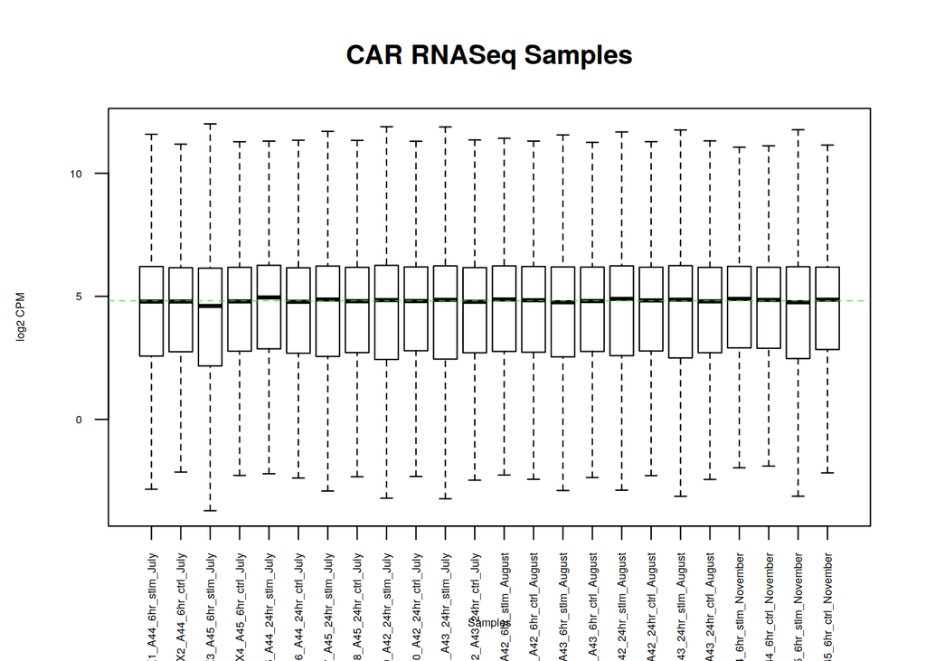

```r
data2plot <- log2(cpm(car_exp_filtered[,2:25]))
box<-boxplot(data2plot, outline=FALSE, xlab = "Samples", ylab = "log2 CPM",
        las = 2, cex = 0.5, cex.lab = 0.5,
        cex.axis = 0.5, main = "CAR RNASeq Samples")

abline(h = median(apply(data2plot, 2, median)), col = "green", lwd
       = 0.6, lty = "dashed")
```

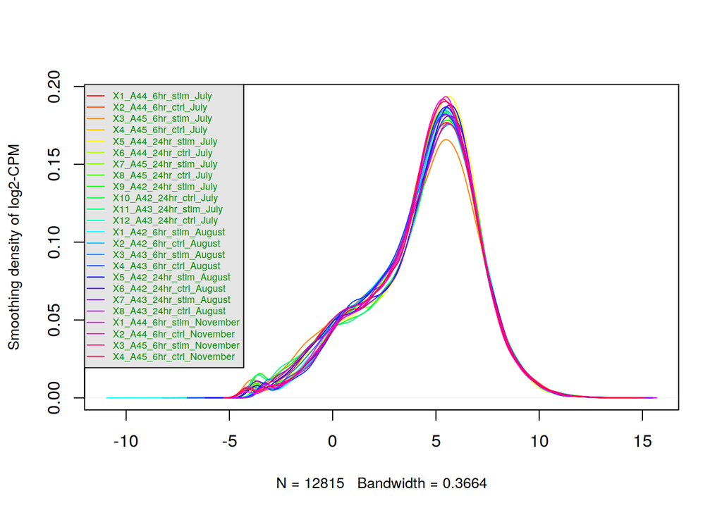

```r
counts_density <- apply(log2(cpm(car_exp_filtered[,2:25])), 2,
                        density)
#calculate the limits across all the samples
xlim <- 0; ylim <- 0
for (i in 1:length(counts_density)) {
  xlim <- range(c(xlim, counts_density[[i]]$x));
  ylim <- range(c(ylim, counts_density[[i]]$y))
}
cols <- rainbow(length(counts_density))
ltys <- rep(1, length(counts_density))
#plot the first density plot to initialize the plot
plot(counts_density[[1]], xlim=xlim, ylim=ylim, type="n",
     ylab="Smoothing density of log2-CPM", main="", cex.lab =
       0.85)
#plot each line
for (i in 1:length(counts_density)) lines(counts_density[[i]],
                                          col=cols[i], lty=ltys[i])
#create legend
legend("topleft",colnames(data2plot),
       col=cols, lty=ltys, cex=0.55,
       border ="blue", text.col = "green4",
       merge = TRUE, bg = "gray90")
```

The above boxplot omitted outliers, the first 100 of 6901 outliers can be shown below:

```r
length(box$out)
```

```
## [1] 6901
```

```r
box$out[1:100]
```

```
##   [1]      -Inf      -Inf      -Inf 12.428958 -3.836686      -Inf      -Inf
##   [8] -3.836686 12.610026      -Inf -3.836686      -Inf      -Inf      -Inf
##  [15]      -Inf      -Inf      -Inf -3.836686 -3.836686 -3.836686 -3.836686
##  [22] -3.836686      -Inf      -Inf      -Inf -3.271089 -3.836686 -3.836686
##  [29] -3.836686      -Inf      -Inf      -Inf      -Inf -3.836686      -Inf
##  [36] 13.589054      -Inf -3.836686 -7.158614      -Inf -3.836686 -3.836686
##  [43]      -Inf -3.836686 -3.458174      -Inf      -Inf      -Inf -3.836686
##  [50]      -Inf 11.731310      -Inf -3.836686      -Inf -3.836686      -Inf
##  [57] 12.279895 12.108942 -3.836686      -Inf -3.836686 -3.836686 11.748864
##  [64]      -Inf -3.836686 -3.836686 -3.836686 -3.836686      -Inf -3.836686
##  [71] -3.836686      -Inf -3.836686      -Inf -3.836686      -Inf -3.836686
##  [78]      -Inf      -Inf -3.836686      -Inf      -Inf -3.836686 -3.836686
##  [85]      -Inf -3.836686      -Inf -3.836686      -Inf -3.836686      -Inf
##  [92]      -Inf 13.993000 12.069054 11.704441 12.216604 12.134314 -3.836686
##  [99]      -Inf -3.836686
```

```r
log2(cpm(car_exp[car_exp$X=="IFNG",c(2,3)]))
```

```
##      X1_A44_6hr_stim_July X2_A44_6hr_ctrl_July
## 6880             19.93157             19.93157
```

## 6. Normalization

The original downloaded data already the result of normalization, according to “RNA-seq data analysis” part of the paper that generate these data( Reference 1), “Raw count data were imported into R. edgeR was used to calculate the normalization factors to scale the raw library sizes, followed by a voom transformation from the limma Bioconductor package”.

But the supplemetary data set is only the raw counts data, so I am doing normalization again.

Package edgeR is chosen because it’s the most common package for Trimmed Mean of the M-values (TMM) normalization method, TMM is chosen because as a “Normalization by distribution” method, it choose a sample as a reference sample, then calculate fold changes and absolute expression levels relative to that sample, as described in Reference 2. It is considered as robust and commonly used method.

Use calcNormFactors function in edgeR package to perform normalization:

```r
filtered_data_matrix <- as.matrix(car_exp_filtered[,2:25])
rownames(filtered_data_matrix) <- car_exp_filtered[,1]
d = DGEList(counts=filtered_data_matrix, group=samples$CAR_type)
d = calcNormFactors(d)
normalized_counts <- cpm(d)
normalized_density <- apply(log2(normalized_counts[,1:24]), 2,
                        density)
```

After normalization, plot the distribution density again:

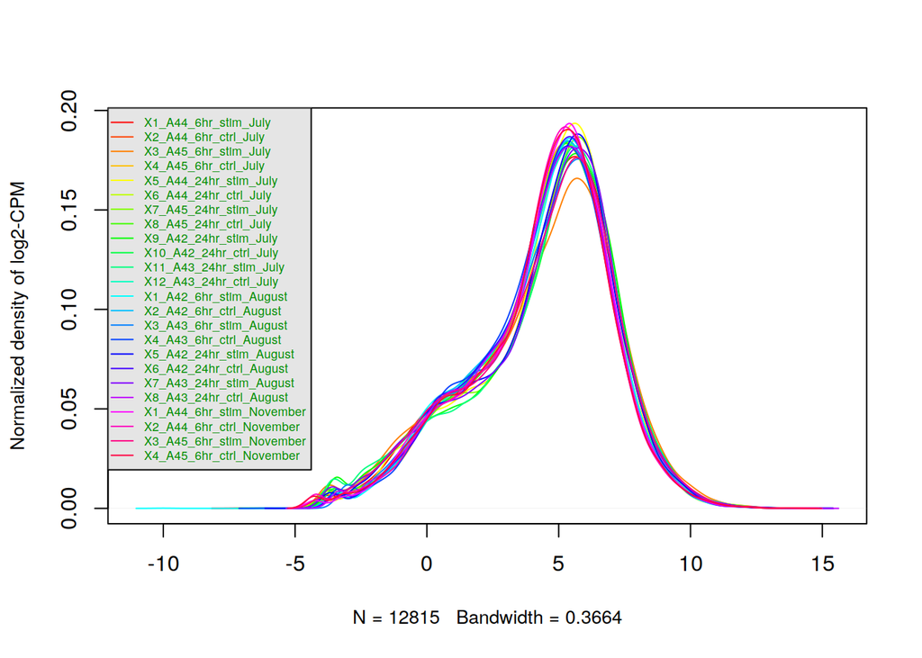

```r
xlim <- 0; ylim <- 0
for (i in 1:length(normalized_density)) {
  xlim <- range(c(xlim, normalized_density[[i]]$x));
  ylim <- range(c(ylim, normalized_density[[i]]$y))
}
cols <- rainbow(length(normalized_density))
ltys <- rep(1, length(normalized_density))

#plot the first density plot to initialize the plot
plot(normalized_density[[1]], xlim=xlim, ylim=ylim, type="n",
     ylab="Normalized density of log2-CPM", main="", cex.lab =
       0.85)
#plot each line
for (i in 1:length(normalized_density)) lines(normalized_density[[i]],
                                          col=cols[i], lty=ltys[i])
#create legend
legend("topleft",colnames(data2plot),
       col=cols, lty=ltys, cex=0.55,
       border ="blue", text.col = "green4",
       merge = TRUE, bg = "gray90")
```

The plot is slightly different from the plot of distribution before normalization, but not much. The two plots have roughly same distribution range.

Also the boxplot:

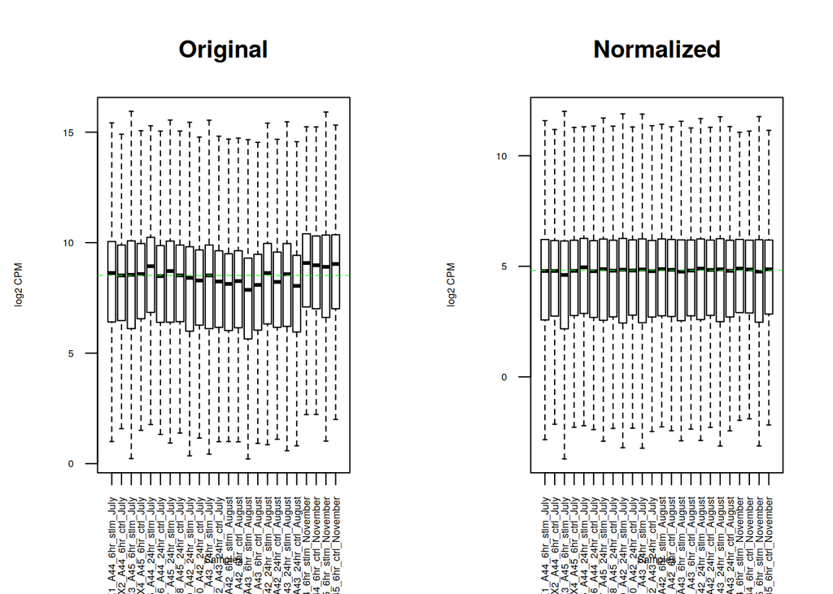

```r
par(fig=c(0,0.48,0,1), new=TRUE)
data2plot <- log2(car_exp_filtered[,2:25])
box<-boxplot(data2plot, outline=FALSE, xlab = "Samples", ylab = "log2 CPM",
        las = 2, cex = 0.5, cex.lab = 0.5,
        cex.axis = 0.5, main = "Original")
abline(h = median(apply(data2plot, 2, median)), col = "green", lwd
       = 0.6, lty = "dashed")

par(fig=c(0.52,1,0,1), new=TRUE)
data2plot2 <- log2(cpm(normalized_counts[,1:24]))
box<-boxplot(data2plot2, outline=FALSE, xlab = "Samples", ylab = "log2 CPM",
        las = 2, cex = 0.5, cex.lab = 0.5,
        cex.axis = 0.5, main = "Normalized")
abline(h = median(apply(data2plot2, 2, median)), col = "green", lwd
       = 0.6, lty = "dashed")
```

Save the data after normalization as final result, also save the filtered raw counts in case needed later:

```r
result<-as.data.frame(normalized_counts )
result_raw <- as.data.frame(car_exp_filtered )
write.csv(result,"result.csv")
write.csv(result_raw,"result_raw.csv")
```

## 7. Compare test and control distribution

The data can be separated to test and control group:

```r
test <- colnames(car_exp)[c(seq(2,24,by=2))]
test_sample <- car_exp[, c("X",test)]
control <- colnames(car_exp)[c(seq(1,25,by=2))]
control_sample <- car_exp[, control]
```

Try showing density plot for test group data:

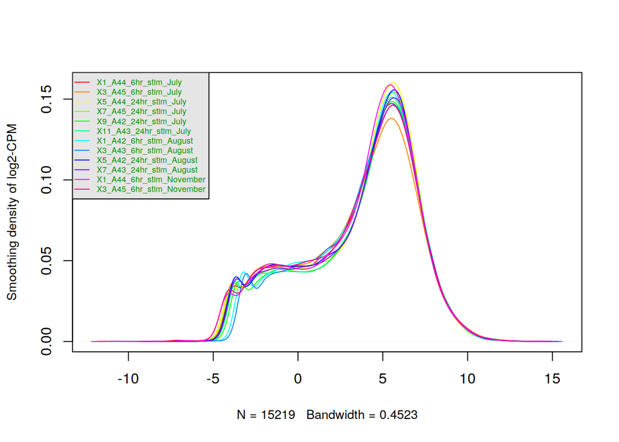

And then control group distribution:

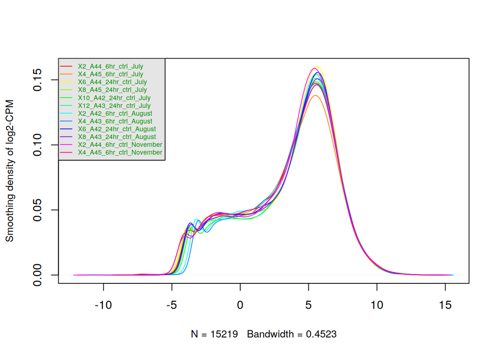

No clear difference can be seen from two plots.

The expression differences are specific for some subsets of genes, it can not be seen from overall disttribution plots.

## 8. Sample separation

Althoght no clear pattern in density distribution plot, sample saparation still can be seen by multidimenstional scaling plot:

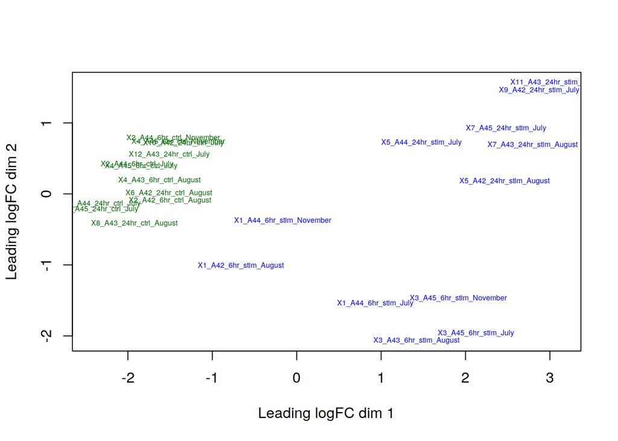

```r
plotMDS(d, labels=rownames(samples),
  col = c("darkgreen","blue")[factor(samples$stim_ctrl)], cex=0.5)
```

Of course this plot is only a visualization, not specific analysis of differential expression.

## Reference

1. Salter, A. I., Ivey, R. G., Kennedy, J. J., Voillet, V., Rajan, A., Alderman, E. J., … Riddell, S. R. (2018). Phosphoproteomic analysis of chimeric antigen receptor signaling reveals kinetic and quantitative differences that affect cell function. Science signaling, 11(544), eaat6753. doi:10.1126/scisignal.aat6753
2. Evans, C., Hardin, J., & Stoebel, D. M. (2018). Selecting between-sample RNA-Seq normalization methods from the perspective of their assumptions. Briefings in bioinformatics, 19(5), 776–792. doi:10.1093/bib/bbx008